## Практична робота №5.Графи. Ациклічні графи

# Мета : набути практичних навичок розв’язання задач топографічного сортування та оцінювання їх асимптотичної складності.

# 1 . Задано ациклічний граф:{1,2,3,4,5,6,7,8,9}{(1,2),(1,3),(2,4),(3,5),(4,5),(4,6),(6,7),(7,8),(8,9)}. Побудувати граф і розв’язати задачу топологічного сортування за допомогою алгоритму DFS

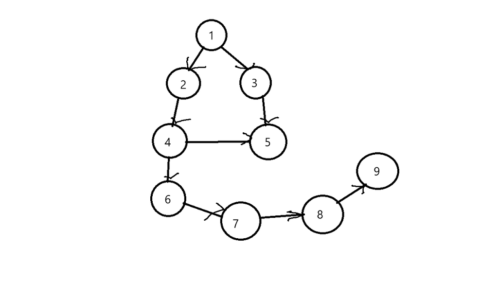

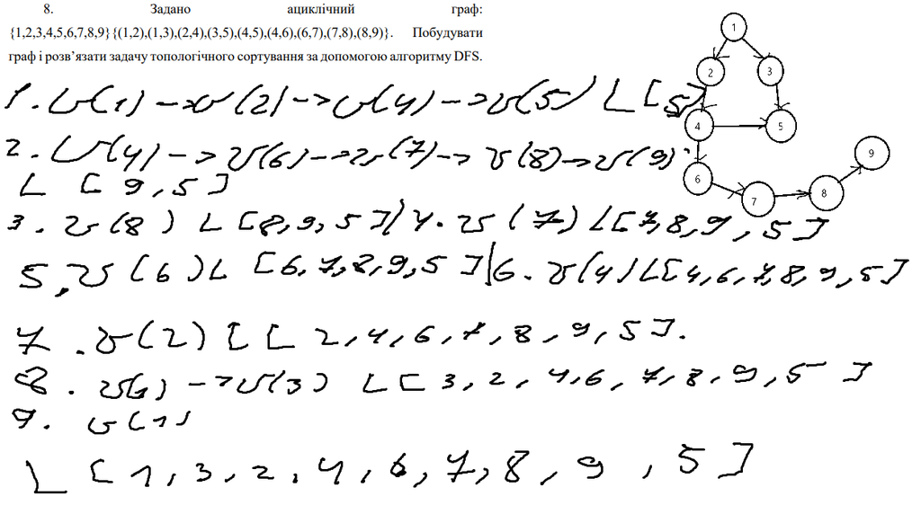

# 2 . Контрольні питання.

- Які переваги і недоліки алгоритму Кана порівняно з алгоритмом DFS для топологічного сортування графа? - алгоритм Кана є ефективнішим для густо зв'язаних графів , а з недоліків , DFS краще для розріджених графів з меншою кількістю вершин.
- Яка складність часу і пам’яті для кожного з алгоритмів у найгіршому і найкращому випадках? - DFS : Найгірший випадок - Часова = O(V+E) Пам'яті = O(V) Найкращий випадок - Часова = O(1) Пам'яті = O(1). Кана : Найгірший випадок - Часова = O(V+E) Пам'яті = O(V+E) Найкращий випадок - Часова = O(V+E) Пам'яті = O(V+E) У Кана ми всеодно проходимо весь граф.
- Чи можна застосовувати алгоритм Кана до графів з вагами на ребрах? Як це порівняти з DFS? - Алгоритм Кана не можна використовувати для графів з вагами , бо він оперує лише структурою графа.DFS можна використовувати для графів з вагами на ребрах , але звичайно краще буде використати інші алгоритми для цього.
- Як впливає структура графа на швидкість роботи кожного з цих алгоритмів - Структура графа має значний вплив на фактичний час виконання DFS. Розріджені та деревоподібні графи обробляються швидше, ніж щільні або глибокі графи.Для алгоритму Кана структура не змінює його асимптотичну складність
- Чи є обмеження використання кожного алгоритму для певних типів графів або завдань? - DFS погано працює з знаходженням найкоротших шляхів у графі , та у тих завданнях що вимагають обходу графа в певному порядку, відмінному від порядку від глибшого до першого. Кана не працює з графами що мають цикли , неорієнтовних графах , в задачах з вагою ребер.
- Які варіанти оптимізації можна застосувати для кожного алгоритму з метою поліпшення його продуктивності? - Для DFS можна покращити порядок сусудів або зробити паралелізацію (якщо структура це дозволяє).Для Кана можна використати списки суміжності або також зробити паралелізацію , знову ж таки якщо це можливо.

# 3 . Висновки.

На практичному занятті ми набули практичних навичок розв’язання задач топографічного сортування та оцінювання їх асимптотичної складності.